# Encuesta de presupuestos Familiares: Primer ET

### Ejercicios

Para resolver uno de los ejercicios tendrán que utilizar la siguiente función de Stringr.

`str_remove()`: remueve lo que se empareje con la expresión regular.

Utilizando las variables de `datos::aeropuertos` encuentre las palabras que sigan los siguientes patrones:

1. Filtrar la base de datos y dejar los nombres que empiecen con “B” o “T” y terminen en vocal.

```r
datos::aeropuertos %>%
  filter(str_detect(nombre, "^[BT].*[aeiou]$")) %>%
  head() %>% gt::gt()
```

| codigo_aeropuerto | nombre | latitud | longitud | altura | zona_horaria | horario_verano | zona_horaria_iana |
| --- | --- | --- | --- | --- | --- | --- | --- |
| BUR | Bob Hope | 34.20067 | -118.35867 | 778 | -8 | A | America/Los_Angeles |
| CNW | Tstc Waco | 31.63783 | -97.07414 | 470 | -6 | A | America/Chicago |
| HRO | Boone Co | 36.26152 | -93.15473 | 1365 | -6 | A | America/Chicago |
| KTB | Thorne Bay Seaplane Base | 55.68806 | -132.53667 | 0 | -9 | A | America/Anchorage |
| PVD | Theodore Francis Green State | 41.73258 | -71.42038 | 55 | -5 | A | America/New_York |
| TCC | Tucumcari Muni | 35.18278 | -103.60319 | 4065 | -7 | A | America/Denver |

2. Filtrar la base de datos y dejar los nombres que se componen de dos palabras.

```r
datos::aeropuertos %>%
  filter(str_detect(nombre, "^\\w+\\s\\w+$")) %>%
  head() %>% gt::gt()
```

| codigo_aeropuerto | nombre | latitud | longitud | altura | zona_horaria | horario_verano | zona_horaria_iana |
| --- | --- | --- | --- | --- | --- | --- | --- |
| 04G | Lansdowne Airport | 41.13047 | -80.61958 | 1044 | -5 | A | America/New_York |
| 06C | Schaumburg Regional | 41.98934 | -88.10124 | 801 | -6 | A | America/Chicago |
| 06N | Randall Airport | 41.43191 | -74.39156 | 523 | -5 | A | America/New_York |
| 1B9 | Mansfield Municipal | 42.00013 | -71.19677 | 122 | -5 | A | America/New_York |
| 1OH | Fortman Airport | 40.55533 | -84.38662 | 885 | -5 | U | America/New_York |
| 23M | Clarke CO | 32.05170 | -88.44340 | 320 | -6 | A | America/Chicago |

3. Crear una nueva variable donde se remueva la palabra “Airport” al final del nombre de los aeropuertos. Extra: ¿Como lo hacemos si queremos eliminar la ultima palabra? (sin eliminar aquellos que son solamente una palabra)

```r
datos::aeropuertos %>%
  mutate(nuevo_nombre = str_remove(nombre, "Airport$")) %>%
  select(nombre, nuevo_nombre) %>%
  slice(1:10) %>% gt::gt()
```

| nombre | nuevo_nombre |
| --- | --- |
| Lansdowne Airport | Lansdowne |
| Moton Field Municipal Airport | Moton Field Municipal |
| Schaumburg Regional | Schaumburg Regional |
| Randall Airport | Randall |
| Jekyll Island Airport | Jekyll Island |
| Elizabethton Municipal Airport | Elizabethton Municipal |
| Williams County Airport | Williams County |
| Finger Lakes Regional Airport | Finger Lakes Regional |
| Shoestring Aviation Airfield | Shoestring Aviation Airfield |
| Jefferson County Intl | Jefferson County Intl |

```r
# Eliminar la ultima palabra
datos::aeropuertos %>%
  mutate(nuevo_nombre = str_remove(nombre, "\\s\\w+$")) %>%
  select(nombre, nuevo_nombre) %>%
  slice(1:10) %>% gt::gt()
```

| nombre | nuevo_nombre |
| --- | --- |
| Lansdowne Airport | Lansdowne |
| Moton Field Municipal Airport | Moton Field Municipal |
| Schaumburg Regional | Schaumburg |
| Randall Airport | Randall |
| Jekyll Island Airport | Jekyll Island |
| Elizabethton Municipal Airport | Elizabethton Municipal |
| Williams County Airport | Williams County |
| Finger Lakes Regional Airport | Finger Lakes Regional |
| Shoestring Aviation Airfield | Shoestring Aviation |
| Jefferson County Intl | Jefferson County |

## Expresiones Regulares: Negaciones y Operadores Lógicos

### Definición y Ejemplo

#### Negaciones

Existe varias maneras de negar las clases de caracteres, en particular ahora vamos a ver las expresiones regulares que son opuestas a las que ya vimos:

- `\\D`: cualquier carácter excepto dígitos.
- `\\W`: cualquier carácter excepto letras o números.
- `\\S`: cualquier carácter excepto espacios.

Cuando se quiere negar una clase personalizada hay que agrega el gorrito `^` dentro de los `corchetes`. En este caso este símbolo no significa lo mismo que cuando está como ancla. Por ejemplo:

- `[^a-zA-Z]`: cualquier carácter menos letras minúsculas y mayúsculas.

```r
str_view(BD$B_NomEdad, "\\D{2,}")
```

[interactive chart not shown]

```r
str_view(BD$B_NomEdad, "[^a-zA-Z]{2,}")
```

[interactive chart not shown]

#### Operadores Lógicos

Por último revisaremos algunas de las operaciones lógicas que se puede aplicar en expresiones regulares:

- `|`: es el operador booleano que entrega valor TRUE si alguno de los operandos son verdaderos.
- `?`: es un operador que indica que el operando puede o no estar. Es decir, es TRUE cuando está y cuando no está el operando.

La manera en que utilizamos estos operadores es la siguiente:

```r
BD %>%
  filter(str_detect(NomB, "^A|^B")) %>% gt::gt()
```

| NomB | B1 | B_NomEdad | B2 | B3 |
| --- | --- | --- | --- | --- |
| Angel | 1 | Juan C 27 | 1 | 3 |
| Bernardo | 2 | Raul T 24 | 2 | 5 |

```r
BD %>%
  filter(str_detect(NomB, "^A|n$")) %>% gt::gt()
```

| NomB | B1 | B_NomEdad | B2 | B3 |
| --- | --- | --- | --- | --- |
| Angel | 1 | Juan C 27 | 1 | 3 |
| Cristian | 3 | Alejandro G xx | 5 | 1 |

```r
BD %>%
  filter(str_detect(B_NomEdad, "\\w [A-Z] \\d?")) %>% gt::gt()
```

| NomB | B1 | B_NomEdad | B2 | B3 |
| --- | --- | --- | --- | --- |
| Angel | 1 | Juan C 27 | 1 | 3 |
| Bernardo | 2 | Raul T 24 | 2 | 5 |
| Cristian | 3 | Alejandro G xx | 5 | 1 |

```r
BD %>%
  filter(str_detect(B_NomEdad, "\\d")
         & str_detect(NomB, "^A")) %>% gt::gt()
```

| NomB | B1 | B_NomEdad | B2 | B3 |
| --- | --- | --- | --- | --- |
| Angel | 1 | Juan C 27 | 1 | 3 |

### Ejercicios

Utilizando la base de datos `datos::nombres` realice los siguientes ejercicios.

1. Filtre los datos para solo tener los datos entre los años 2007 y 2017. Luego filtre para tener solamente los datos del nombre Brian en el tiempo.

```r
datos::nombres %>% slice(1:10) %>% gt::gt()
```

| anio | sexo | nombre | n | prop |
| --- | --- | --- | --- | --- |
| 1880 | F | Mary | 7065 | 0.07238359 |
| 1880 | F | Anna | 2604 | 0.02667896 |
| 1880 | F | Emma | 2003 | 0.02052149 |
| 1880 | F | Elizabeth | 1939 | 0.01986579 |
| 1880 | F | Minnie | 1746 | 0.01788843 |
| 1880 | F | Margaret | 1578 | 0.01616720 |
| 1880 | F | Ida | 1472 | 0.01508119 |
| 1880 | F | Alice | 1414 | 0.01448696 |
| 1880 | F | Bertha | 1320 | 0.01352390 |
| 1880 | F | Sarah | 1288 | 0.01319605 |

```r
nombres %>%
  filter(anio %in% c(2007:2017), str_detect(nombre, "Brian")) %>%
  slice(1:10) %>% gt::gt()
```

| anio | sexo | nombre | n | prop |
| --- | --- | --- | --- | --- |
| 2007 | F | Brianna | 8850 | 0.00418480 |
| 2007 | F | Briana | 2824 | 0.00133535 |
| 2007 | F | Brianne | 187 | 0.00008842 |
| 2007 | F | Briannah | 84 | 0.00003972 |
| 2007 | F | Brianda | 62 | 0.00002932 |
| 2007 | F | Briann | 31 | 0.00001466 |
| 2007 | F | Brian | 23 | 0.00001088 |
| 2007 | F | Briany | 23 | 0.00001088 |
| 2007 | F | Brianny | 22 | 0.00001040 |
| 2007 | F | Brianah | 21 | 0.00000993 |

```r
nombres %>%
  filter(anio %in% c(2007:2017), str_detect(nombre, "Brian$")) %>%
  slice(1:10) %>% gt::gt()
```

| anio | sexo | nombre | n | prop |
| --- | --- | --- | --- | --- |
| 2007 | F | Brian | 23 | 0.00001088 |
| 2007 | M | Brian | 6074 | 0.00274417 |
| 2008 | F | Brian | 9 | 0.00000432 |
| 2008 | M | Brian | 5257 | 0.00241318 |
| 2009 | F | Brian | 6 | 0.00000297 |
| 2009 | M | Brian | 4652 | 0.00219542 |
| 2010 | F | Brian | 8 | 0.00000409 |
| 2010 | M | Brian | 3764 | 0.00183420 |
| 2011 | F | Brian | 5 | 0.00000258 |
| 2011 | M | Brian | 3239 | 0.00159668 |

Podemos sumar la cantidad de Brian por año:

```r
nombres %>%
  filter(anio %in% c(2007:2017), str_detect(nombre, "Brian$")) %>%
  group_by(anio) %>%
  summarise(suma = sum(n)) %>% gt::gt()
```

| anio | suma |
| --- | --- |
| 2007 | 6097 |
| 2008 | 5266 |
| 2009 | 4658 |
| 2010 | 3772 |
| 2011 | 3244 |
| 2012 | 2824 |
| 2013 | 2647 |
| 2014 | 2526 |
| 2015 | 2213 |
| 2016 | 1975 |
| 2017 | 1763 |

2. Tambien podemos escribir brian como “Bryan” ¿como podemos agregar esta consideración a lo que pusimos antes?

```r
nombres %>%
  filter(anio %in% c(2007:2017), str_detect(nombre, "Br[y|i]an$")) %>%
  slice(1:10) %>% gt::gt()
```

| anio | sexo | nombre | n | prop |
| --- | --- | --- | --- | --- |
| 2007 | F | Brian | 23 | 0.00001088 |
| 2007 | F | Bryan | 11 | 0.00000520 |
| 2007 | M | Bryan | 6178 | 0.00279115 |
| 2007 | M | Brian | 6074 | 0.00274417 |
| 2008 | F | Bryan | 14 | 0.00000673 |
| 2008 | F | Brian | 9 | 0.00000432 |
| 2008 | M | Bryan | 5504 | 0.00252656 |
| 2008 | M | Brian | 5257 | 0.00241318 |
| 2009 | F | Bryan | 9 | 0.00000445 |
| 2009 | F | Brian | 6 | 0.00000297 |

Si aplicamos la función para contar la cantidad de personas por año podemos ver que aumenta la cantidad:

```r
nombres %>%
  filter(anio %in% c(2007:2017), str_detect(nombre, "Br[y|i]an$")) %>%
  group_by(anio) %>%
  summarise(suma = sum(n)) %>% gt::gt()
```

| anio | suma |
| --- | --- |
| 2007 | 12286 |
| 2008 | 10784 |
| 2009 | 9520 |
| 2010 | 7717 |
| 2011 | 6769 |
| 2012 | 5913 |
| 2013 | 5535 |
| 2014 | 5260 |
| 2015 | 4699 |
| 2016 | 4100 |
| 2017 | 3590 |

Si queremos solo a los nombres se sexo M:

```r
nombres %>%
  filter(anio %in% c(2007:2017), str_detect(nombre, "Br[y|i]an$")
         & sexo == "M") %>%
  group_by(anio) %>%
  summarise(suma = sum(n)) %>% gt::gt()
```

| anio | suma |
| --- | --- |
| 2007 | 12252 |
| 2008 | 10761 |
| 2009 | 9505 |
| 2010 | 7696 |
| 2011 | 6757 |
| 2012 | 5892 |
| 2013 | 5530 |
| 2014 | 5251 |
| 2015 | 4694 |
| 2016 | 4095 |
| 2017 | 3590 |

```r
nombres %>%
  filter(anio %in% c(2007:2017), str_detect(nombre, "[JY]enn?[eiy][fp]h?er")) %>%
  count(nombre) %>% gt::gt()
```

| nombre | n |
| --- | --- |
| Jenifer | 11 |
| Jenipher | 1 |
| Jennefer | 3 |
| Jennifer | 19 |
| Jennipher | 2 |
| Jennyfer | 11 |
| Jenyfer | 4 |
| Yenifer | 11 |
| Yennifer | 8 |

Luego podemos crear la nueva variable reemplazando el nombre:

```r
nombres %>%
  filter(anio %in% c(2007:2017), str_detect(nombre, "[JY]enn?[eiy][fp]h?er")) %>%
  mutate(nuevo_nombre = str_replace(nombre, "[JY]enn?[eiy][fp]h?er", "Jenni")) %>%
  slice(1:10) %>% gt::gt()
```

| anio | sexo | nombre | n | prop | nuevo_nombre |
| --- | --- | --- | --- | --- | --- |
| 2007 | F | Jennifer | 4648 | 0.00219785 | Jenni |
| 2007 | F | Jenifer | 250 | 0.00011821 | Jenni |
| 2007 | F | Jennyfer | 73 | 0.00003452 | Jenni |
| 2007 | F | Yenifer | 62 | 0.00002932 | Jenni |
| 2007 | F | Yennifer | 21 | 0.00000993 | Jenni |
| 2007 | F | Jennefer | 13 | 0.00000615 | Jenni |
| 2007 | F | Jennipher | 7 | 0.00000331 | Jenni |
| 2007 | F | Jenyfer | 6 | 0.00000284 | Jenni |
| 2007 | M | Jennifer | 7 | 0.00000316 | Jenni |
| 2008 | F | Jennifer | 3791 | 0.00182178 | Jenni |

4. Hacer el mismo ejercicio con Cristofer.

```r
nombres %>%
  filter(anio %in% c(2007:2017), str_detect(nombre, "Ch?risto[fp]h?ere?$")) %>%
  count(nombre) %>% gt::gt()
```

| nombre | n |
| --- | --- |
| Christofer | 11 |
| Christofher | 3 |
| Christoper | 11 |
| Christopher | 21 |
| Cristofer | 11 |
| Cristofher | 6 |
| Cristopher | 11 |

```r
  # Si queremos ver cuantas personas llamadas cristofer por año
nombres %>%
  filter(anio %in% c(2007:2017), str_detect(nombre, "Ch?risto[fp]h?ere?$")) %>%
  group_by(anio) %>%
  summarise(Cantidad  = sum (n)) %>% gt::gt()
```

| anio | Cantidad |
| --- | --- |
| 2007 | 21055 |
| 2008 | 18951 |
| 2009 | 17279 |
| 2010 | 15014 |
| 2011 | 13677 |
| 2012 | 12435 |
| 2013 | 11319 |
| 2014 | 10731 |
| 2015 | 10183 |
| 2016 | 9397 |
| 2017 | 8550 |

También podemos graficar estos resultados

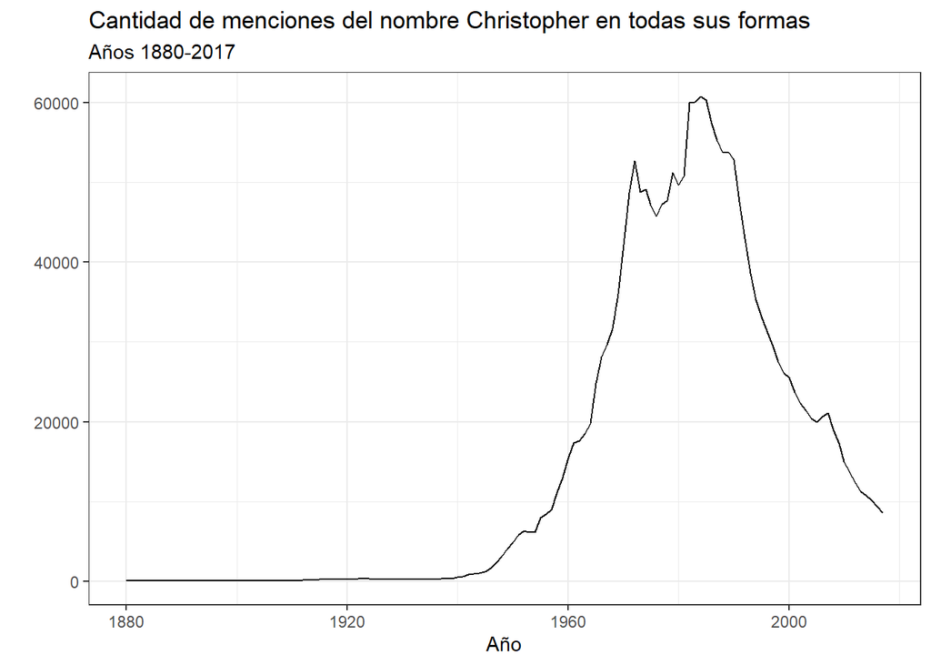

```r
nombres %>%
  filter(str_detect(nombre, "Ch?risto[fp]h?ere?$")) %>%
  group_by(anio) %>%
  summarise(Cantidad  = sum (n)) %>%
  ggplot(aes(x = anio, y  = Cantidad)) +
  geom_line() +
  labs(title = "Cantidad de menciones del nombre Christopher en todas sus formas",
       subtitle = "Años 1880-2017", x = "Año", y = "") +
  theme_bw()
```

## Ejemplo con LGI de la VIII EPF

### Base de datos

Lo primero es extraer 50 casos aleatorios que se relacionen con la palabra “PAN” para efectos del ejemplo.

```r
# Cargamos la base LGI de la VIII
GD <- read_dta("data/LGI_C0.dta")
# Extraemos dos muestra para el ejemplo
set.seed(12345)
GD %>%
  filter(str_detect(GD07, "PAN")) %>%
  sample_n(50) -> GD1
write_dta(GD1, "data//dataER.dta")
```

```r
GD1 <- read_dta("data/dataER.dta")
GD1 %>%
  head() %>%
  select(SUB_MUESTRA, REGION, COMUNA, GD07) %>%
  gt::gt()
```

| SUB_MUESTRA | REGION | COMUNA | GD07 |
| --- | --- | --- | --- |
| 24 | 1 | 1 | PAN HALLULLA A GRANEL |
| 24 | 5 | 1 | PAN CORRIENTE GRANEL |
| 24 | 5 | 1 | PAN CORRIENTE GRANEL |
| 24 | 13 | 27 | EMPANADAS DE MARISCOS |
| 24 | 10 | 1 | PAN HALLULLA GRANEL |
| 24 | 13 | 23 | PAN MARRAQUETA GRANDE A GRANEL |

### Explorar patrones

Luego podemos utilizar el filtro con `str_detect()` para buscar patrones y palabras comunes en la glosa del gasto.

```r
GD1 %>%
  count(GD07) %>%
  gt::gt()
```

| GD07 | n |
| --- | --- |
| PAN CORRIENTE A GRANEL | 1 |
| PAN CORRIENTE GRANEL | 2 |
| 1 KG PAN HALLULLA A GRANEL+8 UND CECINA JAMONADA A GRANEL | 1 |
| EMPANADAS DE MARISCOS | 1 |
| PAN | 1 |
| PAN C/ POLLO PREPARADO | 1 |
| PAN COLISA GRANEL | 1 |
| PAN CORRIENTE | 1 |
| PAN CORRIENTE A GRANEL | 6 |
| PAN CORRIENTE FRESCO A GRANEL | 1 |
| PAN CORRIENTE GRANEL | 13 |
| PAN CORRIENTE GRANEL-MARRAQUETA | 1 |
| PAN CORRIENTE GRANEL MARRAQUETA | 1 |
| PAN DE MOLDE INTEGRAL | 1 |
| PAN DESAYUNO CORRIENTE GRANEL | 1 |
| PAN ESPECIAL A GRANEL | 1 |
| PAN HALLULLA 5 GRANEL | 1 |
| PAN HALLULLA A GRANEL | 2 |
| PAN HALLULLA CORRIENTE A GRANEL | 1 |
| PAN HALLULLA GRANEL | 1 |
| PAN ITALIANO | 1 |
| PAN MARRAQUETA | 1 |
| PAN MARRAQUETA CORRIENTE | 1 |
| PAN MARRAQUETA CORRIENTE A GRANEL | 2 |
| PAN MARRAQUETA GRANDE A GRANEL | 1 |
| PAN MARRAQUETA GRANEL | 1 |
| PAN MARRAQUETAS CORRIENTE A GRANEL | 1 |
| PAN TORTILLA GRANEL | 1 |
| PANES MARRAQUETA A GRANEL | 1 |
| PANES MARRAQUETAS CORRIENTE | 1 |

```r
# Primero vemos aquellas que tienen el caracter especial "+" ya que puede significar que falta desglosar.
GD1 %>%
  filter(str_detect(GD07, "\\+")) %>%
  count(GD07) %>%
  gt::gt()
```

| GD07 | n |
| --- | --- |
| 1 KG PAN HALLULLA A GRANEL+8 UND CECINA JAMONADA A GRANEL | 1 |

```r
# Con marraqueta es más sencillo en este caso porque con poco ya podemos aislar todos los casos
GD1 %>%
  filter(str_detect(GD07, "MARRA")) %>%
  count(GD07) %>%
  gt::gt()
```

| GD07 | n |
| --- | --- |
| PAN CORRIENTE GRANEL-MARRAQUETA | 1 |
| PAN CORRIENTE GRANEL MARRAQUETA | 1 |
| PAN MARRAQUETA | 1 |
| PAN MARRAQUETA CORRIENTE | 1 |
| PAN MARRAQUETA CORRIENTE A GRANEL | 2 |
| PAN MARRAQUETA GRANDE A GRANEL | 1 |
| PAN MARRAQUETA GRANEL | 1 |
| PAN MARRAQUETAS CORRIENTE A GRANEL | 1 |
| PANES MARRAQUETA A GRANEL | 1 |
| PANES MARRAQUETAS CORRIENTE | 1 |

```r
# en el caso de hallulla está el problema de que el caso con el "+" tiene hallulla asi que tenemos que agregar algo para evitarlo
GD1 %>%
  filter(str_detect(GD07, "^(PAN )?HALLU")) %>%
  count(GD07) %>%
  gt::gt()
```

| GD07 | n |
| --- | --- |
| PAN HALLULLA 5 GRANEL | 1 |
| PAN HALLULLA A GRANEL | 2 |
| PAN HALLULLA CORRIENTE A GRANEL | 1 |
| PAN HALLULLA GRANEL | 1 |

```r
# En el caso del pan corriente es más sencillo.
GD1 %>%
  filter(str_detect(GD07, "CORRIENTE")) %>%
  count(GD07) %>%
  gt::gt()
```

| GD07 | n |
| --- | --- |
| PAN CORRIENTE A GRANEL | 1 |
| PAN CORRIENTE GRANEL | 2 |
| PAN CORRIENTE | 1 |
| PAN CORRIENTE A GRANEL | 6 |
| PAN CORRIENTE FRESCO A GRANEL | 1 |
| PAN CORRIENTE GRANEL | 13 |
| PAN CORRIENTE GRANEL-MARRAQUETA | 1 |
| PAN CORRIENTE GRANEL MARRAQUETA | 1 |
| PAN DESAYUNO CORRIENTE GRANEL | 1 |
| PAN HALLULLA CORRIENTE A GRANEL | 1 |
| PAN MARRAQUETA CORRIENTE | 1 |
| PAN MARRAQUETA CORRIENTE A GRANEL | 2 |
| PAN MARRAQUETAS CORRIENTE A GRANEL | 1 |
| PANES MARRAQUETAS CORRIENTE | 1 |

```r
# Podemos separar todo el pan corriente uniendo lo que vimos antes. y al negarlo podemos ver qué nos queda.
GD1 %>%
  filter(str_detect(GD07, "^(PAN)? ?HALLU|MARRAQUETA|CORRIENTE", negate = T)) %>%
  count(GD07) %>%
  gt::gt()
```

| GD07 | n |
| --- | --- |
| 1 KG PAN HALLULLA A GRANEL+8 UND CECINA JAMONADA A GRANEL | 1 |
| EMPANADAS DE MARISCOS | 1 |
| PAN | 1 |
| PAN C/ POLLO PREPARADO | 1 |
| PAN COLISA GRANEL | 1 |
| PAN DE MOLDE INTEGRAL | 1 |
| PAN ESPECIAL A GRANEL | 1 |
| PAN ITALIANO | 1 |
| PAN TORTILLA GRANEL | 1 |

Con los patrones identificados podemos probar una versión lo más concisa posible de la expresión regular para clasificar el pan corriente y especial.

```r
GD1 %>%
  mutate(GD07_2 = case_when(str_detect(GD07, "^PAN$|MARRAQUETA|^(PAN )?HALLULLA|CORRIENTE") ~ "PAN CORRIENTE A GRANEL",
                            str_detect(GD07, "^PAN [A-Z]{2}? ?(GRANEL)?") ~ "PAN ESPECIAL A GRANEL")) -> GD2
```

Podemos observar como queda la nueva variable en los primeros 15 casos

```r
GD2 %>%
  select(GD07, GD07_2) %>%
  slice(1:15) %>% gt::gt()
```

| GD07 | GD07_2 |
| --- | --- |
| PAN HALLULLA A GRANEL | PAN CORRIENTE A GRANEL |
| PAN CORRIENTE GRANEL | PAN CORRIENTE A GRANEL |
| PAN CORRIENTE GRANEL | PAN CORRIENTE A GRANEL |
| EMPANADAS DE MARISCOS | NA |
| PAN HALLULLA GRANEL | PAN CORRIENTE A GRANEL |
| PAN MARRAQUETA GRANDE A GRANEL | PAN CORRIENTE A GRANEL |
| PAN CORRIENTE GRANEL MARRAQUETA | PAN CORRIENTE A GRANEL |
| PAN CORRIENTE GRANEL | PAN CORRIENTE A GRANEL |
| PAN HALLULLA CORRIENTE A GRANEL | PAN CORRIENTE A GRANEL |
| PAN C/ POLLO PREPARADO | NA |
| PAN ESPECIAL A GRANEL | PAN ESPECIAL A GRANEL |
| PAN CORRIENTE FRESCO A GRANEL | PAN CORRIENTE A GRANEL |
| PAN CORRIENTE GRANEL | PAN CORRIENTE A GRANEL |
| PAN CORRIENTE GRANEL | PAN CORRIENTE A GRANEL |
| PAN CORRIENTE A GRANEL | PAN CORRIENTE A GRANEL |

Podemos aislar los casos que no calzan con la expresion regular

```r
GD2 %>%
  select(GD07, GD07_2) %>%
  filter(str_detect(GD07, "^(PAN )?HALLU|MARRAQUETA|CORRIENTE", negate = T)) %>% gt::gt()
```

| GD07 | GD07_2 |
| --- | --- |
| EMPANADAS DE MARISCOS | NA |
| PAN C/ POLLO PREPARADO | NA |
| PAN ESPECIAL A GRANEL | PAN ESPECIAL A GRANEL |
| 1 KG PAN HALLULLA A GRANEL+8 UND CECINA JAMONADA A GRANEL | NA |
| PAN COLISA GRANEL | PAN ESPECIAL A GRANEL |
| PAN | PAN CORRIENTE A GRANEL |
| PAN ITALIANO | PAN ESPECIAL A GRANEL |
| PAN TORTILLA GRANEL | PAN ESPECIAL A GRANEL |
| PAN DE MOLDE INTEGRAL | PAN ESPECIAL A GRANEL |

Luego agregamos un nuevo criterio y unimos ambas columnas con `dplyr::coalesce`:

```r
GD2 %>%
  mutate(GD07_3 = case_when(str_detect(GD07,"EMPANADA|POLLO") ~ "OTRO"),
         GD07_0 = coalesce(GD07_2, GD07_3)) %>%
  select(-matches("GD07_[1-9]")) -> GD3

GD3 %>%
  select(GD07, GD07_0) %>% gt::gt()
```

| GD07 | GD07_0 |
| --- | --- |
| PAN HALLULLA A GRANEL | PAN CORRIENTE A GRANEL |
| PAN CORRIENTE GRANEL | PAN CORRIENTE A GRANEL |
| PAN CORRIENTE GRANEL | PAN CORRIENTE A GRANEL |
| EMPANADAS DE MARISCOS | OTRO |
| PAN HALLULLA GRANEL | PAN CORRIENTE A GRANEL |
| PAN MARRAQUETA GRANDE A GRANEL | PAN CORRIENTE A GRANEL |
| PAN CORRIENTE GRANEL MARRAQUETA | PAN CORRIENTE A GRANEL |
| PAN CORRIENTE GRANEL | PAN CORRIENTE A GRANEL |
| PAN HALLULLA CORRIENTE A GRANEL | PAN CORRIENTE A GRANEL |
| PAN C/ POLLO PREPARADO | OTRO |
| PAN ESPECIAL A GRANEL | PAN ESPECIAL A GRANEL |
| PAN CORRIENTE FRESCO A GRANEL | PAN CORRIENTE A GRANEL |
| PAN CORRIENTE GRANEL | PAN CORRIENTE A GRANEL |
| PAN CORRIENTE GRANEL | PAN CORRIENTE A GRANEL |
| PAN CORRIENTE A GRANEL | PAN CORRIENTE A GRANEL |
| PAN MARRAQUETA CORRIENTE A GRANEL | PAN CORRIENTE A GRANEL |
| PAN MARRAQUETAS CORRIENTE A GRANEL | PAN CORRIENTE A GRANEL |
| PAN CORRIENTE GRANEL | PAN CORRIENTE A GRANEL |
| PAN CORRIENTE A GRANEL | PAN CORRIENTE A GRANEL |
| PAN MARRAQUETA CORRIENTE A GRANEL | PAN CORRIENTE A GRANEL |
| PAN CORRIENTE GRANEL | PAN CORRIENTE A GRANEL |
| PAN CORRIENTE GRANEL | PAN CORRIENTE A GRANEL |
| PAN CORRIENTE GRANEL | PAN CORRIENTE A GRANEL |
| PAN MARRAQUETA GRANEL | PAN CORRIENTE A GRANEL |
| PAN CORRIENTE GRANEL | PAN CORRIENTE A GRANEL |
| 1 KG PAN HALLULLA A GRANEL+8 UND CECINA JAMONADA A GRANEL | NA |
| PANES MARRAQUETAS CORRIENTE | PAN CORRIENTE A GRANEL |
| PAN CORRIENTE A GRANEL | PAN CORRIENTE A GRANEL |
| PAN CORRIENTE GRANEL | PAN CORRIENTE A GRANEL |
| PAN CORRIENTE GRANEL-MARRAQUETA | PAN CORRIENTE A GRANEL |
| PAN CORRIENTE A GRANEL | PAN CORRIENTE A GRANEL |
| PAN DESAYUNO CORRIENTE GRANEL | PAN CORRIENTE A GRANEL |
| PAN COLISA GRANEL | PAN ESPECIAL A GRANEL |
| PAN HALLULLA A GRANEL | PAN CORRIENTE A GRANEL |
| PAN CORRIENTE | PAN CORRIENTE A GRANEL |
| PAN CORRIENTE GRANEL | PAN CORRIENTE A GRANEL |
| PAN MARRAQUETA CORRIENTE | PAN CORRIENTE A GRANEL |
| PAN CORRIENTE A GRANEL | PAN CORRIENTE A GRANEL |
| PAN CORRIENTE A GRANEL | PAN CORRIENTE A GRANEL |
| PAN MARRAQUETA | PAN CORRIENTE A GRANEL |
| PAN CORRIENTE GRANEL | PAN CORRIENTE A GRANEL |
| PAN CORRIENTE GRANEL | PAN CORRIENTE A GRANEL |
| PAN CORRIENTE GRANEL | PAN CORRIENTE A GRANEL |
| PAN CORRIENTE A GRANEL | PAN CORRIENTE A GRANEL |
| PAN | PAN CORRIENTE A GRANEL |
| PAN ITALIANO | PAN ESPECIAL A GRANEL |
| PAN TORTILLA GRANEL | PAN ESPECIAL A GRANEL |
| PAN DE MOLDE INTEGRAL | PAN ESPECIAL A GRANEL |
| PANES MARRAQUETA A GRANEL | PAN CORRIENTE A GRANEL |
| PAN HALLULLA 5 GRANEL | PAN CORRIENTE A GRANEL |

Finalmente podemos ver la cantidad de elementos clasificados.

```r
GD3 %>%
  count(GD07_0) %>% gt::gt()
```

| GD07_0 | n |
| --- | --- |
| OTRO | 2 |
| PAN CORRIENTE A GRANEL | 42 |
| PAN ESPECIAL A GRANEL | 5 |
| NA | 1 |

### Ejemplo de adaptación del do.file

```r
# GD %>%
#   filter(
#     str_detect(GD07, pattern = "HALLULA|MARRAQUETA|BATIDO|FRANCES|CORRIENTE|SURTIDO")
#     & str_detect(GD07, pattern = "PAN")
#     & str_detect(GD07, negate = TRUE, pattern = "CIGARRO|S/SAL|PALTA|JAMON|QUESO|\\sCON\\s|PREPARADO|ESPECIAL|ENVASAD|ENVASE|MOLDE|INTEGRAL|LINAZA|PITA|BOLSA|\\+|\\,|\\-|PAQUETE|\\sY\\s|LECHE|DESCUENTO|CHURRASCA|SANDWICH|SIN\\sSAL|S/SAL|COMPLETO|FRICA|HAMBURGUESA|AMASADO|COLISA|COLIZA|TOSCANO|HOJA|CHOCOSO|DOBLADA|DOBLADITA|HARINA|BONIFICACION") # Descripción del gasto
#     & str_detect(GD10, pattern = "ALMACEN|AMASANDERIA|PANADERIA|MINIMARKET|ABARROTE|SUPERMERCADO|NEGOCIO|BAZAR|LIDER|JUMBO|SANTAISA|EKONO|UNIMARC|TOTTUS|MAYORISTA10|MONSERRAT|MONTSERRAT|ALVI|PROVISIONES") # Establecimiento
#     & str_detect(GD06, negate = TRUE, pattern = "PAQUETE|BOLSA") # Unidad de Medida
#   ) %>%
  # select(GD07)
```

Adaptación con pequeñas variaciones de expresión regular.

```r
# GD %>%
#   filter(
#     str_detect(GD07, pattern = "^PAN$|HALLULA|MARRAQUETA|BATIDO|FRANCES|CORRIENTE|SURTIDO")
#     & str_detect(GD07, pattern = "PAN")
#     & str_detect(GD07, negate = TRUE, pattern = "CIGARRO|S/SAL|PALTA|JAMON|QUESO|\\sCON\\s|PREPARADO|ESPECIAL|ENVASAD|ENVASE|MOLDE|INTEGRAL|LINAZA|PITA|BOLSA|\\+|\\,|\\-|PAQUETE|\\sY\\s|LECHE|DESCUENTO|CHURRASCA|SANDWICH|SIN\\sSAL|S/SAL|COMPLETO|FRICA|HAMBURGUESA|AMASADO|COLI[S|Z]A|TOSCANO|HOJA|CHOCOSO|DOBLADA?(ITA)?|HARINA|BONIFICACION") # Descripción del gasto
#     & str_detect(GD10, pattern = "ALMACEN|AMASANDERIA|PANADERIA|MINIMARKET|ABARROTE|SUPERMERCADO|NEGOCIO|BAZAR|LIDER|JUMBO|SANTAISA|EKONO|UNIMARC|TOTTUS|MAYORISTA10|MONSERRAT|MONTSERRAT|ALVI|PROVISIONES") # Establecimiento
#     & str_detect(GD06, negate = TRUE, pattern = "PAQUETE|BOLSA") # Unidad de Medida
#   ) %>%
#   select(GD07)
```

# Bibliografía y Material Complementario

**Expresiones regulares**

- [Documento en CRAN sobre regex](https://cran.r-project.org/web/packages/stringr/vignettes/regular-expressions.html)
- [Tutotial Regex](https://regexone.com/problem/extracting_url_data?)
- [Taller de R-ladies Santiago sobre Regex](https://github.com/rladieschile/taller-regex-2021)

**Stringr**

- [R for Data Science capitulo 14: Strings](https://r4ds.had.co.nz/strings.html)
- [Stringr en el tidyverse](https://stringr.tidyverse.org/)

**Paquetes adicionales**

- [Strex: paquete que expande las funciones de Stringr](https://github.com/rorynolan/strex)
- [Glue: paquete para pegar considerando objetos de R](https://github.com/tidyverse/glue)
[^1]: Este documento fue construido con las herramientas de Rmarkdown en Rstudio por Juan Gabriel Carrasco (jgcarrascob@ine.gob.cl), con la colaboración de Felipe Pizarro (fapizarror@ine.gob.cl)